# Análisis de los resultados del modelado para Máster

En este análisis se realiza un análisis de los resultados obtenidos con el modelo realizado para los alumnos de Máster.

En este sentido, se ha realizado lo siguiente:

1. Se obtienen las métricas del modelo en el conjunto test.
2. Se observa la matriz de confusión para los matriculados y no matriculados, comparando el real con el predicho.
3. Se comparan las tasas de matriculación obtenidas con el predicho y las reales en las 5 principales titulaciones.
4. Se analizan las distribuciones de la probabilidad en cada una de las distintas etapas.
5. Se mira las distribuciones de la probabilidad de matrícula en las 5 titulaciones top.
6. Se mira la importancia de las variables dentro del modelo utilizado.

```
--------------------------------------------------
      VIRTUDES Y MÉTRICAS DEL MODELO DE ADMISIÓN
--------------------------------------------------
✅ Porcentaje de Acierto (Accuracy): 91.90%
🎯 Capacidad de Discriminación (AUC-ROC): 0.9686
📊 Precisión (Cuando predice Sí, ¿cuánto acierta?): 93.63%
📈 Sensibilidad (¿A cuántos del total captura?): 92.50%
🛡️ Especificidad (Capacidad de detectar No-Matrícula): 91.05%
--------------------------------------------------

ANÁLISIS ESTRATÉGICO:
⭐ El modelo tiene un rendimiento EXCELENTE. La separación entre perfiles es muy clara.
💡 De cada 100 matrículas reales, el modelo identifica correctamente a 92 candidatos.
💡 El modelo es especialmente bueno descartando (Especificidad: 91.05%), lo que ahorra esfuerzo comercial.
--------------------------------------------------
```

## 2. Matriz de confusión global

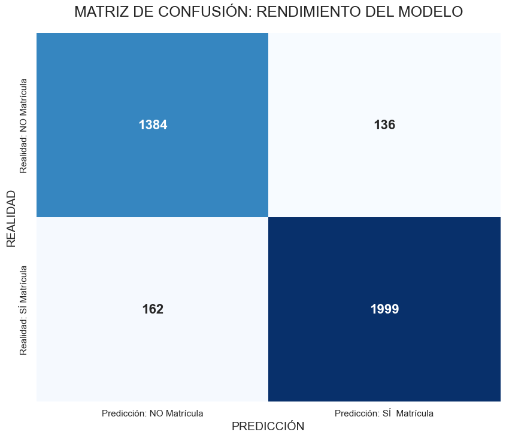

```
Exactitud (Accuracy): 91.90%
Precisión (Certeza de Matrícula): 93.63%
```

Aquí se puede observar que el modelo acierta en el 91% de los casos y que, dentro de los matriculados, acierta en casi el 94% de los casos.

## 3. Comparación tasa real de matriculación con la predicha en el top 5 de titulaciones

```
--------------------------------------------------
      VIRTUDES DEL MODELO (SOBRE OPORTUNIDADES ÚNICAS)
--------------------------------------------------
✅ Exactitud Global (Accuracy): 94.16%
🎯 Área bajo la curva (AUC): 0.9794
📊 Precisión de Matrícula: 92.36%
📈 Capacidad de Captación (Recall): 84.71%
--------------------------------------------------
```

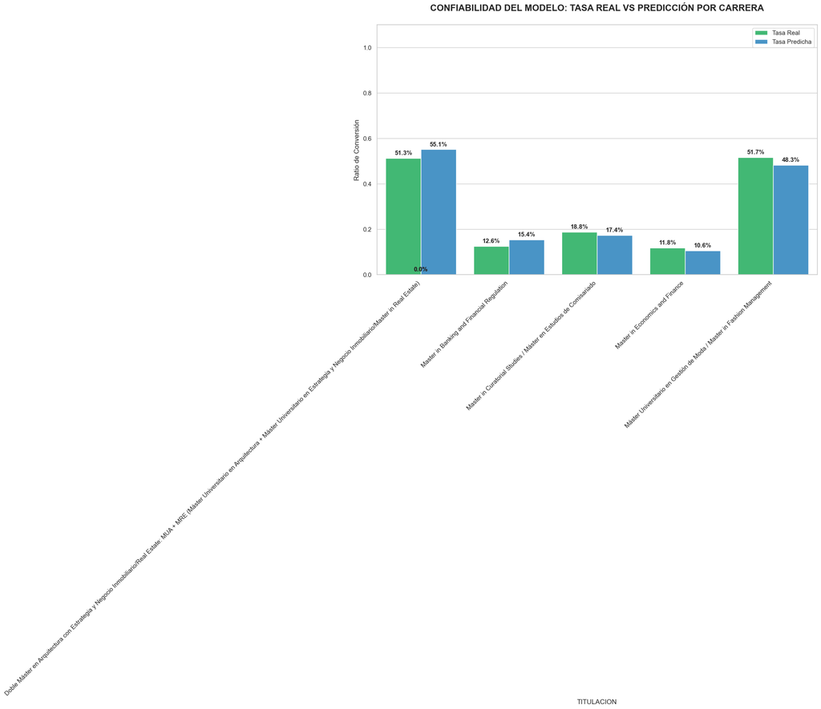

## 4. Evolución de la probabilidad de matrícula por etapa

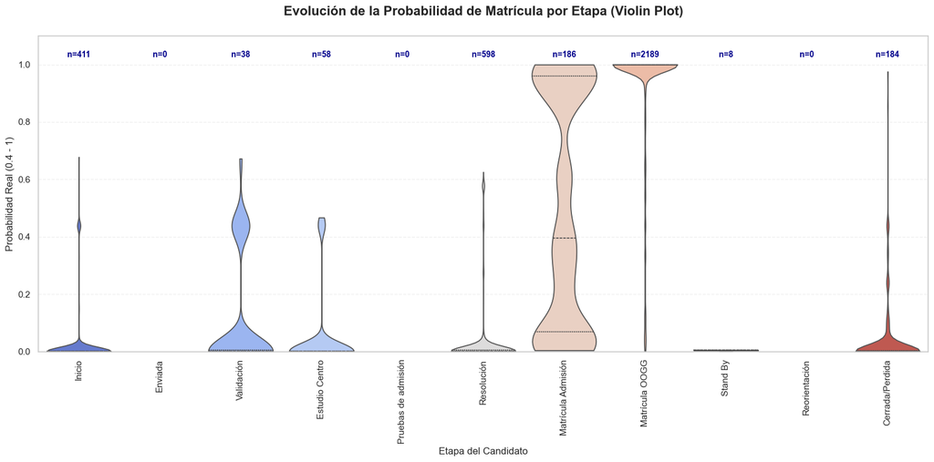

Aquí se pueden ver que hay etapas en las que claramente, la probabilidad de matrícula son muy bajas. En cambio, en la etapa de Matrícula admisión, ya se ven probabilidades más extendidas, y que es una de las etapas críticas, ya que hay muchos valores bajos como altos. Sin embargo, en la etapa Matrícula OOGG ya se tienen todas las probabilidades concentradas en valores muy altos.

## Distribución de probabilidades en el top 5 de titulaciones

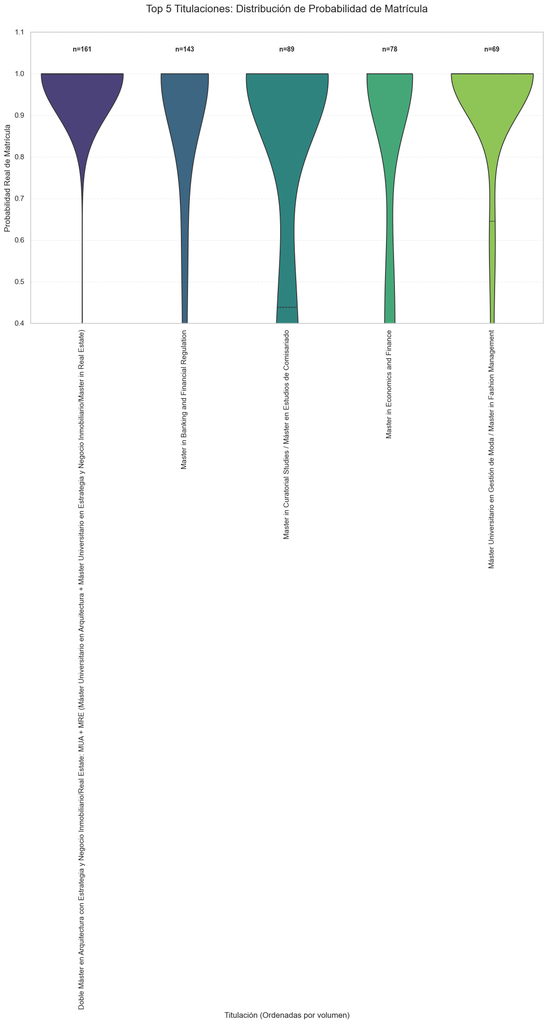

Aquí se puede obserbar que los patrones son muy parecidos entre sí:

- Hay perfiles muy distintos entre sí con probabilidades altas. Y suele pasar en todos los másters.

## Importancia de variables

```
Transformation Pipeline and Model Successfully Loaded
⚠️ Ajustando: Modelo tiene 17 variables pero se detectaron 18 nombres.
```

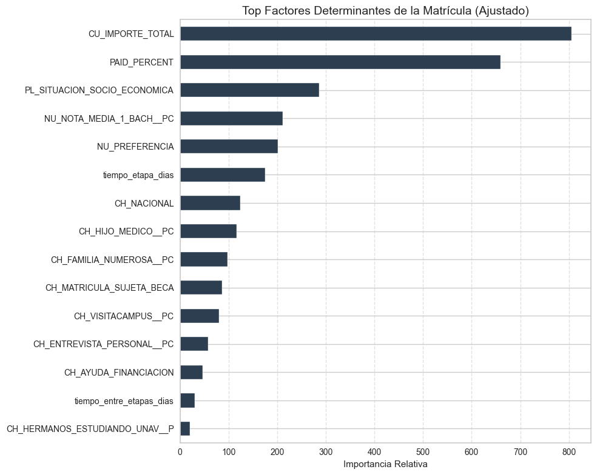

Aquí, al igual que en grado, las variables más importantes son: el importe total de la matrícula, el pocentaje que ha pagado y la situación socioeconómica. Seguido de la nota de bachillerato, la preferencia y su situación social; es decir, si es hijo de médico, familia numerosa, etc.